# Agrupamiento Espectral con el Dataset de Vinos

Vamos en este ejercicio a considerar una base de datos de vinos real. Es un Dataset que posee 3 clases de vinos descritos por diferentes características físicas (color) y organolépticas (alcohol, acido málico...). Esta base da datos es difícil de agrupar. Por ejemplo, si usamos el agrupamiento jerárquico, no sale demasiado bien la separación de las 3 clases con ningún 'linkage'. Vamos a estudiar el Dataset con la técnica de agrupamiento espectral.

Vamos a proceder exactamente igual que como la Parte 1 de esta práctica.Vamos a desarrollar el agrupamiento espectral por nosotros/as mismo/as

Vamos a cargar de nuevo el Dataset

```python
import sys
import pandas as pd



from sklearn import preprocessing


data = pd.read_csv("wine.csv")
#Daros cuenta de que en el csv los datos estan ordenados por tipo de vino (primero Barolo luego Grignolino...)



#print(data.head())

#Obtenemos los datos brutos sin etiquetas de 'ground truth'
#es decir obtenemos las columnas de datos 'alcohol','malic_acid' ...
data_raw = data.drop(columns=['class_label', 'class_name'])

#obtenemos las etiquetas (ground truth)
#es decir ,la columna 'class_label'
labels = data['class_label']

#la convertimos en un array
wlabels=labels.to_numpy()

wlabels = wlabels.flatten()

data_nump =  data_raw.to_numpy()

#Preprocesado. Vamos a normalizar los datos
min_max_scaler = preprocessing.MinMaxScaler()
wines_minmax = min_max_scaler.fit_transform(data_nump)
```

Vamos ahora a obtener el grafo y la matriz de adyacencia del mismo

```python
from sklearn.neighbors import kneighbors_graph
from scipy import sparse


data_df = wines_minmax
#numero de vecinos
nn=8
# Adjacency Matrix.
connectivity = kneighbors_graph(X=data_df, n_neighbors=nn, mode='connectivity')
print(connectivity)
adjacency_matrix_s = (1/2)*(connectivity + connectivity.T)
print("-------")
print()
print(adjacency_matrix_s)
```

```
  (0, 20)	1.0
  (0, 56)	1.0
  (0, 40)	1.0
  (0, 22)	1.0
  (0, 54)	1.0
  (0, 29)	1.0
  (0, 9)	1.0
  (0, 6)	1.0
  (1, 38)	1.0
  (1, 29)	1.0
  (1, 22)	1.0
  (1, 54)	1.0
  (1, 23)	1.0
  (1, 26)	1.0
  (1, 27)	1.0
  (1, 44)	1.0
  (2, 55)	1.0
  (2, 48)	1.0
  (2, 30)	1.0
  (2, 51)	1.0
  (2, 57)	1.0
  (2, 35)	1.0
  (2, 10)	1.0
  (2, 12)	1.0
  (3, 52)	1.0
  :	:
  (174, 165)	1.0
  (175, 149)	1.0
  (175, 166)	1.0
  (175, 176)	1.0
  (175, 174)	1.0
  (175, 148)	1.0
  (175, 167)	1.0
  (175, 144)	1.0
  (175, 156)	1.0
  (176, 153)	1.0
  (176, 175)	1.0
  (176, 148)	1.0
  (176, 154)	1.0
  (176, 166)	1.0
```

[output cut: 49 more lines]

```
  (176, 166)	1.0
  (176, 154)	1.0
  (176, 148)	0.5
  (176, 175)	1.0
  (176, 153)	1.0
  (177, 159)	0.5
  (177, 158)	0.5
  (177, 165)	0.5
  (177, 172)	0.5
  (177, 173)	1.0
  (177, 155)	1.0
  (177, 166)	0.5
  (177, 148)	0.5
  (177, 174)	0.5
  (177, 156)	1.0
```

**Cuestión 0:** ¿qué técnica has usado para generar el grafo?

**Respuesta:** Utilizamos la técnica de los k-vecinos más cercanos. Se crea un grafo dirigido debido a que la relación de vecindad no sigue una simetría. Este tipo de grafo conecta cada punto con sus k-vecinos más cercanos según la distancia, reflejando las relaciones locales entre los puntos en un espacio de alta dimensión. El grafo resultante ofrece insights sobre la estructura de los datos, brindándonos información valiosa para llevar a cabo el análisis.

Calculamos ahora la matriz laplaciana y la visualizamos con un mapa de calor

```
  (0, 39)	-0.5
  (0, 7)	-0.5
  (0, 6)	-0.5
  (0, 9)	-0.5
  (0, 29)	-0.5
  (0, 54)	-0.5
  (0, 22)	-1.0
  (0, 40)	-1.0
  (0, 56)	-1.0
  (0, 20)	-1.0
  (1, 44)	-0.5
  (1, 27)	-1.0
  (1, 26)	-0.5
  (1, 23)	-0.5
  (1, 54)	-0.5
  (1, 22)	-1.0
  (1, 29)	-0.5
  (1, 38)	-1.0
  (2, 50)	-0.5
  (2, 12)	-0.5
  (2, 10)	-0.5
  (2, 35)	-0.5
  (2, 57)	-0.5
  (2, 51)	-1.0
  (2, 30)	-1.0
  :	:
  (153, 153)	7.5
  (154, 154)	6.5
  (155, 155)	7.5
  (156, 156)	10.5
  (157, 157)	5.0
  (158, 158)	4.5
  (159, 159)	4.5
  (160, 160)	6.5
  (161, 161)	9.0
  (162, 162)	9.5
  (163, 163)	11.0
  (164, 164)	9.0
  (165, 165)	11.0
  (166, 166)	10.5
  (167, 167)	10.5
  (168, 168)	10.0
  (169, 169)	5.0
  (170, 170)	11.5
  (171, 171)	7.5
  (172, 172)	9.5
  (173, 173)	7.5
  (174, 174)	15.5
  (175, 175)	8.0
  (176, 176)	8.5
  (177, 177)	6.5
```

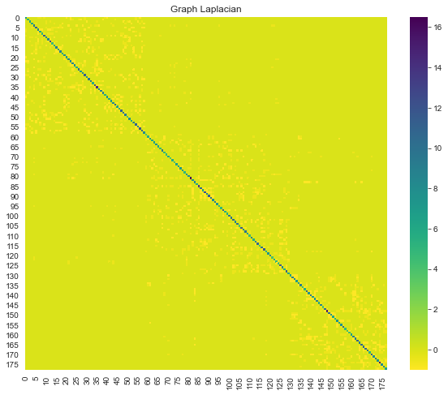

```python
#librerías y configuración para los gráficos
import matplotlib.pyplot as plt
import seaborn as sns
sns.set_style('darkgrid', {'axes.facecolor': '.9'})
sns.set_palette(palette='deep')
sns_c = sns.color_palette(palette='deep')
%matplotlib inline

# Graph Laplacian.
graph_laplacian_s = sparse.csgraph.laplacian(csgraph=adjacency_matrix_s, normed=False)
graph_laplacian = graph_laplacian_s.toarray()

# Plot the graph Laplacian as heat map.
fig, ax = plt.subplots(figsize=(10, 8))
sns.heatmap(graph_laplacian, ax=ax, cmap='viridis_r')
ax.set(title='Graph Laplacian');

print(graph_laplacian_s)
```

**Cuestión 1:** Observa que, aunque es una matriz dispersa, entorno a la diagonal principal hay una organización de valores en tres cuadrados que no son ceros (valores en amarillo (negativos)). Aunque es un poco premeditado avanzar un diagnóstico ¿Consideras que esto es un buen síntoma o un mal síntoma del futuro agrupamiento (Nota: la situación es en parte semejante a la descrita en las diapositivas de teoria 14 y 15)

**Respuesta:** Una organización de valores no nulos alrededor de la diagonal principal, indica cierto patrón o relación entre las variables representadas en la matriz. La presencia de valores negativos puede sugerir una correlación negativa o alguna relación inversa entre las variables correspondientes.

Vamos a hora a calcular los autovalores y autovectores de la matriz

```python
from scipy import linalg
import numpy as np

eigenvals, eigenvcts = linalg.eig(graph_laplacian)
```

Como sabemos, al ser la matriz laplaciana de un grafo simétrica y semidefinida positiva, sus autovalores son valores reales y además tienen valor cero y valores positivos. Vamos a comprobarlo tambien para este Dataset. Primero comprobamos que el único valor que aparecen la parte imaginaria de los autovalores son 0 (lo que indica que son reales).

```python
np.unique(np.imag(eigenvals))
```

```
array([0.])
```

Una vez comprobado, eliminamos la parte compleja.

```python
eigenvals = np.real(eigenvals)
eigenvcts = np.real(eigenvcts)
```

Ordenamos los autovalores por valor creciente

```python
from sklearn.preprocessing import normalize


eigenvals_sorted_indices = np.argsort(eigenvals)
eigenvals_sorted = eigenvals[eigenvals_sorted_indices]

#Sacamos el grado de multiplicidad del autovalor de valor 0
zero_eigenvals_index = np.argwhere(abs(eigenvals_sorted) < 1e-5)
print(zero_eigenvals_index )
print("***************")


indices = eigenvals_sorted_indices[: 3]
proj_df = pd.DataFrame(eigenvcts[:, indices])
print(proj_df)
proj_df.columns = ['v_' + str(c) for c in proj_df.columns]

proj_df = normalize(proj_df)
print("-+-+-+-+")
print(proj_df)
```

```
[[0]]
***************
            0         1         2
0   -0.074953 -0.083063  0.066862
1   -0.074953 -0.076576  0.046818
2   -0.074953 -0.086940  0.083684
3   -0.074953 -0.091044  0.099440
4   -0.074953 -0.063051  0.008531
..        ...       ...       ...
173 -0.074953  0.111569  0.062464
174 -0.074953  0.111346  0.062441
175 -0.074953  0.114268  0.069242
176 -0.074953  0.112669  0.064757
177 -0.074953  0.116073  0.072732

[178 rows x 3 columns]
-+-+-+-+
[[-0.57506785 -0.63729133  0.51298803]
 [-0.64098239 -0.65486051  0.40037392]
 [-0.52763629 -0.61201525  0.5890987 ]
 [-0.48589636 -0.59020852  0.64463837]
 [-0.76236387 -0.64130471  0.08677328]
 [-0.5007195  -0.59788587  0.62594925]
 [-0.55993454 -0.62834747  0.54004886]
 [-0.56296005 -0.63023754  0.53467431]
 [-0.54436179 -0.6215608   0.56332265]
 [-0.58870432 -0.64006429  0.49370531]
 [-0.49933024 -0.5972135   0.62769846]
 [-0.60978483 -0.64310498  0.46322612]
 [-0.56869314 -0.62861305  0.5305033 ]
 [-0.50907213 -0.60125394  0.61590524]
 [-0.47889901 -0.58573449  0.65388901]
 [-0.52369182 -0.60938457  0.59531279]
 [-0.52350306 -0.60948602  0.59537495]
 [-0.55154964 -0.6215587   0.55628929]
 [-0.47923541 -0.58589638  0.65349741]
 [-0.6510225  -0.6598052   0.37526898]
 [-0.58985681 -0.64296883  0.48852843]
 [-0.77489488 -0.63207809 -0.00390087]
 [-0.61019024 -0.64846544  0.45514882]
```

[output cut: 140 more lines]

```
 [-0.57777676  0.76220979  0.29190794]
 [-0.49056263  0.74662704  0.44932879]
 [-0.53506622  0.76091222  0.36703777]
 [-0.48183606  0.74313668  0.46430797]
 [-0.49478335  0.74808497  0.44221976]
 [-0.48391175  0.74325103  0.4619603 ]
 [-0.48294831  0.74173359  0.46539469]
 [-0.60872962  0.75941729  0.22963803]
 [-0.52785948  0.75955829  0.38004681]
 [-0.48349134  0.74443085  0.46049847]
 [-0.50570904  0.75275664  0.42144491]
 [-0.50631482  0.7521543   0.42179285]
 [-0.48925731  0.74588301  0.45197989]
 [-0.49962424  0.75102981  0.43165941]
 [-0.48002731  0.74337066  0.46580451]]
```

Visualizamos los autovalores en una gráfica

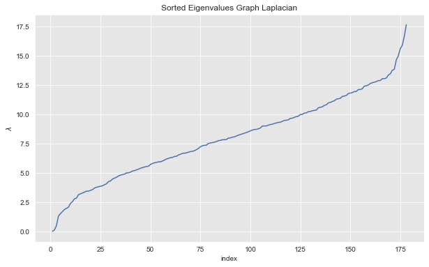

```python
fig, ax = plt.subplots(figsize=(10, 6))
sns.lineplot(x=range(1, eigenvals_sorted_indices.size + 1), y=eigenvals_sorted, ax=ax)

ax.set(title='Sorted Eigenvalues Graph Laplacian', xlabel='index', ylabel=r'$\lambda$');
```

Vamos a ampliar la región del comienzo de la gráfica para ver ahora el comportamiento de los primeros autovalores, que son los que aportan más información.

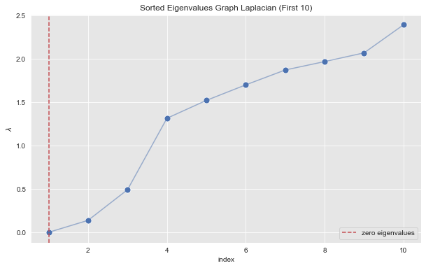

```python
#elegimos el número de autovalores que queremos visualizar
index_lim = 10

fig, ax = plt.subplots(figsize=(10, 6))
sns.scatterplot(x=range(1, eigenvals_sorted_indices[: index_lim].size + 1), y=eigenvals_sorted[: index_lim], s=80, ax=ax)
sns.lineplot(x=range(1, eigenvals_sorted_indices[: index_lim].size + 1), y=eigenvals_sorted[: index_lim], alpha=0.5, ax=ax)
ax.axvline(x=1, color=sns_c[3], label='zero eigenvalues', linestyle='--')
ax.legend()
ax.set(title=f'Sorted Eigenvalues Graph Laplacian (First {index_lim})', xlabel='index', ylabel=r'$\lambda$');
```

**Cuestión 2:** ¿En qué ha cambiado este diagrama respecto al que has obtenido en la Parte 1 de esta práctica (Dataset de tres anillos)?

**Respuesta:** En contraste con el gráfico obtenido en la Parte 1, el análisis de la descomposición espectral en este caso nos revela la presencia de un único componente conectado en el grafo, representado por el número de valores 0.

Visualiza ahora los valores de las componentes del segundo autovector. Recuerda que por teoría sabes que este autovector sería la solución (la agrupación) al problema del corte de un grafo (si no hubieramos relajado las condiciones). En cualquier caso, en este problema puede aportar mucha información acerca del etiquetado de los datos.

```python
indicesegundo = eigenvals_sorted_indices[1]
#imprimimos las dimensiones de este autovector para comprobar que son las esperadas
print(eigenvcts[:,indicesegundo].shape)
```

```
(178,)
```

Lo visualizamos en una gráfica

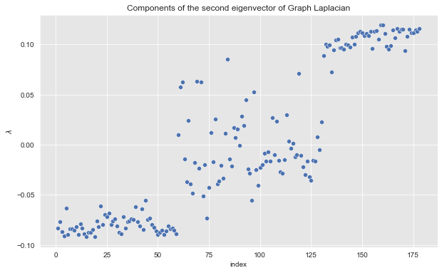

```python
fig2, ax2 = plt.subplots(figsize=(10, 6))
sns.scatterplot(x=range(1, eigenvals_sorted_indices.size + 1), y=eigenvcts[:,indicesegundo], ax=ax2)
#ax2.scatter(x=range(1, eigenvals_sorted_indices.size + 1), y=eigenvcts[:,indicecuarto])
ax2.set(title='Components of the second eigenvector of Graph Laplacian', xlabel='index', ylabel=r'$\lambda$');
```

**Cuestion3:** Recuerda cómo usamos los valores del autovector segundo en el agrupamiento espectral. ¿Qué puedes decir acerca de esta gráfica? ¿Podríamos a la vista de estos resultados dejar de utilizar más autovectores para agrupar los datos?

**Respuesta:** El gráfico nos muestra cómo cambian las características de cada punto de datos, representadas por las componentes del segundo autovector.

Cuando los puntos están cerca, significa que son parecidos, y en este caso, vemos dos grupos bien definidos. También notamos una zona alrededor del valor 0 donde hay cambios bruscos, indicando diferentes agrupamientos, posiblemente representando distintos conjuntos. En total, identificamos tres áreas diferentes de agrupamiento.

Observar las características del segundo autovector es esencial para abordar el problema del corte del grafo. Los autovectores asociados a los autovalores más bajos tienen la capacidad de capturar cómo se divide la estructura, lo que, en términos sencillos, significa separar los datos en grupos o conjuntos.

Vamos a usar estos valores de las componentes del segundo autovector como solucion del problema de agrupamiento de nuestro dataset. Establece unos rangos de valores de las componentes que diferencien las fronteras de los grupos de componentes que ves en el gráfico y crea un vector con valores '0', '1', y '2' que representen la pertenencia de las componentes del autovector a un grupo en concreto. Es decir genera un vector en el que si su valor del índice '1' es '0', significa que la componente de índice '1' del autovector pertenece al agrupamiento '0'

```python
etiquetas_espectrales = np.zeros(eigenvcts[:,indicesegundo].shape[0])

segundo_eigenvector = eigenvcts[:,indicesegundo]

for i in range(0,segundo_eigenvector.shape[0]):
    if segundo_eigenvector[i] <= -0.05 :
        etiquetas_espectrales[i] = 0
    elif -0.05 < segundo_eigenvector[i] <= 0.07:
        etiquetas_espectrales[i] = 1
    elif segundo_eigenvector[i] > 0.07:
        etiquetas_espectrales[i] = 2

print(etiquetas_espectrales)
```

```
[0. 0. 0. 0. 0. 0. 0. 0. 0. 0. 0. 0. 0. 0. 0. 0. 0. 0. 0. 0. 0. 0. 0. 0.
 0. 0. 0. 0. 0. 0. 0. 0. 0. 0. 0. 0. 0. 0. 0. 0. 0. 0. 0. 0. 0. 0. 0. 0.
 0. 0. 0. 0. 0. 0. 0. 0. 0. 0. 0. 1. 1. 1. 1. 1. 1. 1. 1. 1. 1. 1. 1. 0.
 1. 0. 1. 1. 1. 1. 1. 1. 1. 1. 1. 2. 1. 1. 1. 1. 1. 1. 1. 1. 1. 1. 1. 0.
 1. 1. 1. 1. 1. 1. 1. 1. 1. 1. 1. 1. 1. 1. 1. 1. 1. 1. 1. 1. 1. 1. 2. 1.
 1. 1. 1. 1. 1. 1. 1. 1. 1. 1. 2. 2. 2. 2. 2. 2. 2. 2. 2. 2. 2. 2. 2. 2.
 2. 2. 2. 2. 2. 2. 2. 2. 2. 2. 2. 2. 2. 2. 2. 2. 2. 2. 2. 2. 2. 2. 2. 2.
 2. 2. 2. 2. 2. 2. 2. 2. 2. 2.]
```

Usamos estas etiquetas para visualizar ahora los datos del vino. Para ello, **usa los datos del Dataset original (normalizados)** y visualiza solo las caracteristicas de alcohol y acido málico coloreandolas con este vector de etiquetas procedente del agrupamiento espectral.

```
[Text(0.5, 1.0, 'Agrupamiento espectral con el segundo autovector')]
```

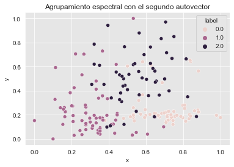

```python
df = pd.DataFrame(np.array([wines_minmax[:,0],wines_minmax[:,1], etiquetas_espectrales]).transpose(), columns =['x', 'y', 'label'])

fig, ax = plt.subplots()
sns.scatterplot(x='x', y='y', data=df, hue='label', ax=ax)
ax.set(title='Agrupamiento espectral con el segundo autovector')
```

Compáralo con el verdadero agrupamiento, visualizando estas componentes del Dataset con la columna de las etiquetas verdaderas (recuerda que las tienes en un vector llamado wlabels)

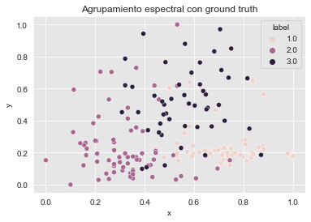

```python
df = pd.DataFrame(np.array([wines_minmax[:,0],wines_minmax[:,1], wlabels]).transpose(), columns =['x', 'y', 'label'])

fig, ax = plt.subplots()
sns.scatterplot(x='x', y='y', data=df, hue='label', ax=ax)
ax.set(title='Agrupamiento espectral con ground truth');
```

**Cuestión 4:** Describe los resultados de las dos gráficas e indica tus conclusiones.

En el primer gráfico, se emplea el método de agrupamiento espectral utilizando el segundo autovector. Las etiquetas espectrales se determinan mediante un umbral aplicado al segundo autovector, y los puntos dispersos se colorean en función de estas etiquetas.

En el segundo gráfico, se realiza el agrupamiento espectral con base en el "ground truth" o verdad fundamental. En este caso, se disponen de etiquetas reales, y los puntos se colorean de acuerdo con estas etiquetas.

Al comparar ambos gráficos, se evidencia una alta concordancia entre el agrupamiento espectral (etiquetas espectrales) y el agrupamiento real (etiquetas reales). Los puntos dispersos se representan de manera consistente en ambos casos. Esto hace que el método de agrupamiento espectral haya capturado de manera efectiva la estructura subyacente de los datos.